# predicting_ed_outcomes

# Results

With two models developed and tested on the trainingsets’ partitioned evaluation set, this section now tests each model on the final_holdout_set.

Starting with feature engineering and NA check on the final holdout set

```r
# Step 1: Feature Engineering
#apply feature engineering function to final_holdout_set
final_holdout_set <- feature_engineering(final_holdout_set)
# Apply the feature engineering validation function
validation_holdout_results <- validate_features(final_holdout_set)
```

```
## Total NA Count in Dataset: 8
## [1] "NA Counts for Each Feature:"
## # A tibble: 63 × 2
##    Feature                      NA_Count
##    <chr>                           <int>
##  1 prior_std_grade_1st_sem             4
##  2 prior_std_grade_2nd_sem             4
##  3 marital_status                      0
##  4 application_mode                    0
##  5 application_order                   0
##  6 course                              0
##  7 daytime_evening_attendance          0
##  8 previous_qualification              0
##  9 previous_qualification_grade        0
## 10 nacionality                         0
## # ℹ 53 more rows
## No features have 100% 0s or 1s.
```

```r
# There are 8 NAs. A negligable amount. So they are dropped
cat("Total NA Count in final_holdout_set  before removal:", sum(is.na(final_holdout_set)), "\n")
```

```
## Total NA Count in final_holdout_set  before removal: 8
```

```r
final_holdout_set <- final_holdout_set %>% drop_na()
cat("Total NA Count in final_holdout_set after removal:", sum(is.na(final_holdout_set)), "\n")
```

```
## Total NA Count in final_holdout_set after removal: 0
```

```r
# Step 2: Set Target as factor
# Ensure the target variable in the final_holdout_set is a factor
final_holdout_set$target <- as.factor(final_holdout_set$target)
```

With the final holdout set now having the same treatment as the traindata set from which the models were developed, predictions can be made.

```r
# Predict with Decision Tree Model
dt_holdout_predictions <- predict(decision_tree_model, final_holdout_set, type = "class")
dt_holdout_conf_matrix <- confusionMatrix(dt_holdout_predictions, final_holdout_set$target)
cat("Decision Tree Results on Final Holdout Set:\n")
```

```
## Decision Tree Results on Final Holdout Set:
```

```r
print(dt_holdout_conf_matrix)
```

```
## Confusion Matrix and Statistics
##
##           Reference
## Prediction   1   2   3
##          1 226  62  23
##          2   0   0   0
##          3  67  85 417
##
## Overall Statistics
##
##                Accuracy : 0.7307
##                  95% CI : (0.7001, 0.7597)
##     No Information Rate : 0.5
##     P-Value [Acc > NIR] : < 2.2e-16
##
##                   Kappa : 0.5182
##
##  Mcnemar's Test P-Value : < 2.2e-16
##
## Statistics by Class:
##
##                      Class: 1 Class: 2 Class: 3
## Sensitivity            0.7713    0.000   0.9477
## Specificity            0.8552    1.000   0.6545
## Pos Pred Value         0.7267      NaN   0.7329
## Neg Pred Value         0.8822    0.833   0.9260
## Prevalence             0.3330    0.167   0.5000
## Detection Rate         0.2568    0.000   0.4739
## Detection Prevalence   0.3534    0.000   0.6466
## Balanced Accuracy      0.8133    0.500   0.8011
```

```r
# Predict with Gradient Boosted Trees Model
gbt_holdout_predictions <- predict(gbt_model, final_holdout_set)
gbt_holdout_conf_matrix <- confusionMatrix(gbt_holdout_predictions, final_holdout_set$target)
cat("Gradient Boosted Trees Results on Final Holdout Set:\n")
```

```
## Gradient Boosted Trees Results on Final Holdout Set:
```

```r
print(gbt_holdout_conf_matrix)
```

```
## Confusion Matrix and Statistics
##
##           Reference
## Prediction   1   2   3
##          1 217  38  27
##          2  39  56  17
##          3  37  53 396
##
## Overall Statistics
##
##                Accuracy : 0.7602
##                  95% CI : (0.7306, 0.7881)
##     No Information Rate : 0.5
##     P-Value [Acc > NIR] : < 2.2e-16
##
##                   Kappa : 0.5976
##
##  Mcnemar's Test P-Value : 0.0001626
##
## Statistics by Class:
##
##                      Class: 1 Class: 2 Class: 3
## Sensitivity            0.7406  0.38095   0.9000
## Specificity            0.8893  0.92360   0.7955
## Pos Pred Value         0.7695  0.50000   0.8148
## Neg Pred Value         0.8729  0.88151   0.8883
## Prevalence             0.3330  0.16705   0.5000
## Detection Rate         0.2466  0.06364   0.4500
## Detection Prevalence   0.3205  0.12727   0.5523
## Balanced Accuracy      0.8149  0.65228   0.8477
```

Now, we will visualize GBT & Decision Tree Performance on Final Holdout

```r
#Function to plot confusion matrix heatmap
plot_confusion_matrix <- function(conf_matrix, model_name) {
  conf_matrix_df <- as.data.frame(conf_matrix$table)
  ggplot(conf_matrix_df, aes(x = Reference, y = Prediction, fill = Freq)) +
    geom_tile(color = "white") +
    geom_text(aes(label = Freq), color = "white", fontface = "bold") +
    scale_fill_gradient(low = "lightblue", high = "darkblue") +
    labs(
      title = paste("Confusion Matrix Heatmap for", model_name, "Model"),
      x = "Actual Class",
      y = "Predicted Class"
    ) +
    theme_minimal() +
    theme(
      axis.text.x = element_text(angle = 45, hjust = 1),
      plot.title = element_text(size = 14, face = "bold", hjust = 0.5)
    )
}
```

Now visualize it DT model

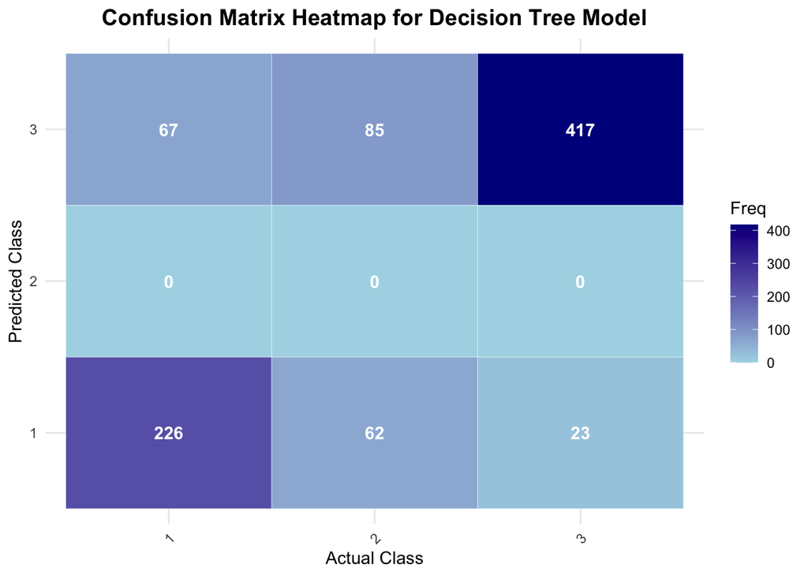

```r
# Visualize Decision Tree Model
dt_conf_matrix_plot <- plot_confusion_matrix(dt_holdout_conf_matrix, "Decision Tree")
print(dt_conf_matrix_plot)
```

Now visualize the GBT Model performance

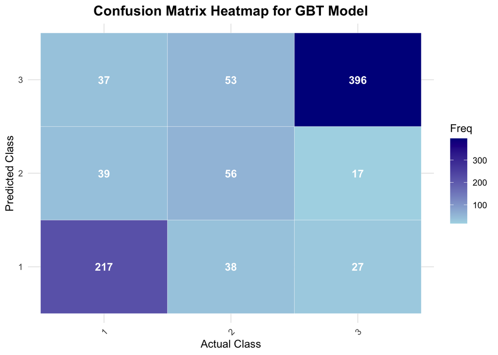

```r
# Visualize Gradient Boosted Trees Model
gbt_conf_matrix_plot <- plot_confusion_matrix(gbt_holdout_conf_matrix, "GBT")
print(gbt_conf_matrix_plot)
```

# Conclusion

In conclusion, this report has cleaned the dataset, explored the variables, built new features, and developed two mmachine learning models to predict student outcomes at university (dropout, enrolled, graduate). The two models developed were decision trees & gradiaent boosted trees. The performance of these two models are mediocre at best. Due to class imbalance, precision/pos predictive value is one of the best measures of success. As shown above, GBT performs much better than decision trees in this regaard (DT = 0.7267 NaN 0.7329) vs (GPT = 0.7695 0.50000 0.8148). # This difference is largely due to cross validation and the use of boosted sampling for mis-classified target in it’s training. However, with GBT only identified 38% of enrolled students (sensitivity), as a result, the model is left wanting.

On the positive side, enrolled is the least important group for prediction since it is the most easily identified in the present. Notably, accurately predicting 74% of dropouts and 90% (sensitivity) of graduates are strong outcomes and suggests that with further refinement as discussed in the following section greater outcomes can be achieved.

## Limitations

The dataset has several limitations that constrain the analysis and predictive modeling. One key limitation is the lack of longitudinal data, which prevents analyzing year-over-year trends in enrollment, graduation, and dropout rates. Incorporating temporal data could reveal how outcomes evolve annually, offering valuable insights for intervention planning.

Another limitation is the absence of information on financial support. Financial aid is a known predictor of student outcomes, but the dataset does not include details about the university’s financial aid policies. This restricts the ability to assess how financial support impacts dropout and graduation rates. Including such data in future analyses could provide a more comprehensive understanding.

The dataset also does not clearly map courses to specific degree programs. This missing connection makes it challenging to identify the unique support needs of students pursuing different academic paths. Establishing these relationships could improve the ability to tailor interventions to individual degree programs.

Class imbalance and limited data further challenge model performance. The dataset contains 62 features but only 3539 students, with a significant imbalance in class distribution. For example, only 647 students are currently enrolled (class 2), which complicates the models’ ability to learn effectively and increases susceptibility to overfitting.

```r
ncol(traindata)
```

```
## [1] 63
```

```r
nrow(traindata)
```

```
## [1] 3539
```

```r
table(traindata$target)
```

```
##
##    1    2    3
## 1124  647 1768
```

The complexity of the features relative to the dataset size also introduces noise and reduces the generalizability of the models. Dimensionality reduction or feature selection could help mitigate this issue and improve predictive accuracy. Lastly, the high number of features and limited sample size have resulted in signs of overfitting in the decision tree and gradient-boosted tree models. This indicates the need for simpler models, additional data, or regularization techniques to enhance performance on unseen data.

## Future Directions

Many variables in the dataset were not explored further because their predictability in their current form was insufficient to warrant immediate feature development. Variables with coefficients near zero in the regression plot, for instance, were largely left unexamined. This creates an opportunity to develop new features, particularly demographic ones, such as more detailed descriptions of parent occupation and educational qualifications, which could provide better insights into factors that increase or decrease the likelihood of success in university.

Class imbalance remains a key challenge in the analysis. While some strategies were employed, such as cross-validation in gradient-boosted trees, additional methods like SMOTE (Synthetic Minority Oversampling Technique) or weighted loss functions could further enhance performance for minority classes. Neither the decision tree nor gradient-boosted tree models explicitly utilized techniques such as oversampling, undersampling, or class-weighted learning, leaving room for improvement in handling imbalanced data.

Future research could also explore elastic net or lasso regression to strategically select the most relevant features for predictive modeling. Another potential avenue is reframing the problem as a two-class classification task, focusing solely on distinguishing between graduates and dropouts. This simplified approach could yield more actionable insights for supporting at-risk students.

Lastly, a probabilistic approach, such as multinomial logistic regression, could provide counselors and stakeholders with actionable probabilities of students falling into dropout, enrollment, or graduation categories. Such a model would equip decision-makers with the nuanced information needed to prioritize early interventions and support strategies effectively.

# Citations

- Realinho, V., Vieira Martins, M., Machado, J., & Baptista, L. (2021). Predict Students’ Dropout and Academic Success [Dataset]. UCI Machine Learning Repository. https://doi.org/10.24432/C5MC89.
- U.S. Department of Education, National Center for Education Statistics, Integrated Postsecondary Education Data System (IPEDS), Winter 2020–21, Graduation Rates component. See Digest of Education Statistics 2021, table 326.20. Retreieved on 11/25/24 from https://nces.ed.gov/fastfacts/display.asp?id=40
- US Department of Health and Human Services. (2023). Enrollment in higher education. Enrollment in Higher Education - Healthy People 2030. https://odphp.health.gov/healthypeople/priority-areas/social-determinants-health/literature-summaries/enrollment-higher-education